# Bayesian Analysis of Spatial Proteomics data using pRoloc

Oliver Crook and Laurent Gatto

29 September 2018

#### Package

pRoloc 1.21.8

# 1 Introduction

For an in-depth description of the infrastructure for Bayesian spatial proteomics, please see

> A Bayesian Mixture Modelling Approach For Spatial Proteomics Oliver M Crook, Claire M Mulvey, Paul D. W. Kirk, Kathryn S Lilley, Laurent Gatto bioRxiv 282269; doi: https://doi.org/10.1101/282269

Analysis of the spatial sub-cellular distribution of proteins is of vital importance to fully understand context specific protein function. Some proteins can be found with a single location within a cell, but up to half of proteins may reside in multiple locations, can dynamically relocalise, or reside within an unknown functional compartment. These considerations lead to uncertainty in associating a protein to a single location. Currently, mass spectrometry (MS) based spatial proteomics relies on supervised machine learning algorithms to assign proteins to sub-cellular locations based on common gradient profiles. However, such methods fail to quantify uncertainty associated with sub-cellular class assignment. Here we reformulate the framework on which we perform statistical analysis. We propose a Bayesian generative classifier based on Gaussian mixture models to assign proteins probabilistically to sub-cellular niches, thus proteins have a probability distribution over sub-cellular locations, with Bayesian computation performed using the expectation-maximisation (EM) algorithm (coined TAGM-MAP, for *maximum a posteriori*), as well as Markov-chain Monte-Carlo (coined TAGM-MCMC). Our methodology allows proteome-wide uncertainty quantification, thus adding a further layer to the analysis of spatial proteomics. Our framework is flexible, allowing many different systems to be analysed and reveals new modelling opportunities for spatial proteomics. We find our methods perform competitively with current state-of-the art machine learning methods, whilst simultaneously providing more information. We highlight several examples where classification based on the support vector machine is unable to make any conclusions, while uncertainty quantification using our approach provides biologically intriguing results. To our knowledge this is the first Bayesian model of MS-based spatial proteomics data.

Below, we start by loading packages that are needed to execute the code in this vignette and set the default colour to semi-transparent.

```r
library("pRoloc")
library("pRolocdata")
require("reshape")
require("ggplot2")
require("coda")
setStockcol(NULL)
setStockcol(paste0(getStockcol(), 90))
```

# 2 The *TAGM-MAP* method

We will use a subsest of the `tan2009r1` dataset from the *pRolocdata* to illustrate the TAGM-MAP method

```r
data(tan2009r1)
set.seed(1)
tan2009r1 <- tan2009r1[sample(nrow(tan2009r1), 400), ]
```

The first step is to generate the model parameters using the `tagmMapTrain` function, that will generate an instance of class `MAPParams`.

```r
p <- tagmMapTrain(tan2009r1, )
p
```

```
## Object of class "MAPParams"
##  Method: MAP
```

The results of the modelling can be visualised with the `plotEllipse` function. The outer ellipse contains 99% of the total probability whilst the middle and inner ellipses contain 95% and 90% of the probability respectively. The centres of the clusters are represented by black circumpunct (circled dot).

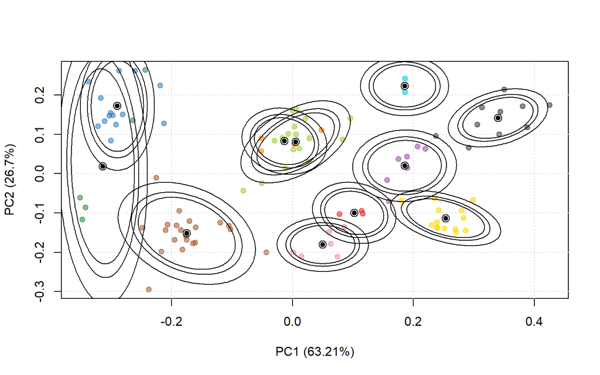

```r
plotEllipse(tan2009r1, p)
```

The `MAPParams` object can now be used to classify the proteins of unknown localisation using `tagmPredict`.

```r
res <- tagmPredict(tan2009r1, p)
```

The new feature variables that are generated are:

- `tagm.map.allocation`: the TAGM-MAP predictions for the most likely protein sub-cellular allocation.

```r
table(fData(res)$tagm.map.allocation)
```

```
##
##  Cytoskeleton            ER         Golgi      Lysosome mitochondrion
##            17            95            24             8            34
##       Nucleus    Peroxisome            PM    Proteasome  Ribosome 40S
##            25             3           114            19            30
##  Ribosome 60S
##            31
```

- `tagm.map.probability`: the posterior probability for the protein sub-cellular allocations.

```r
summary(fData(res)$tagm.map.probability)
```

```
##      Min.   1st Qu.    Median      Mean   3rd Qu.      Max.
## 0.0000000 0.0003256 0.0049051 0.2731639 1.0000000 1.0000000
```

- `tagm.map.outlier`: the probability for that protein to belong to the outlier component rather than any annotated component.

```r
summary(fData(res)$tagm.map.outlier)
```

```
##    Min. 1st Qu.  Median    Mean 3rd Qu.    Max.
##  0.0000  0.0000  0.9948  0.7266  0.9996  1.0000
```

# 3 The *TAGM-MCMC* method

We will use a subsest of the `tan2009r1` dataset from the *pRolocdata* to illustrate the TAGM-MCMC method

The first step is run two MCMC chains for a few iterations of the algorithm using the `tagmMcmcTrain` function. This function will generate a object of class `MCMCParams`. The summary slot of which is currently empty.

```r
library("pRoloc")
p <- tagmMcmcTrain(object = tan2009r1, numIter = 3,
                   burnin = 1, thin = 1, numChains = 2)
p
```

```
## Object of class "MCMCParams"
## Method: TAGM.MCMC
## Number of chains: 2
```

Information for each MCMC chain is contained within the chains slot. This information can be accessed manually if need. The function `MCMCProcess` populates the summary slot of the `MCMCParams` object

```r
p <- tagmMcmcProcess(p)
p
```

```
## Object of class "MCMCParams"
## Method: TAGM.MCMC
## Number of chains: 2
## Summary available
```

The summary slot has now been populated to include basic summaries of the `MCMCChains`, such as allocations and localisation probabilities. Protein information can be appended to the feature columns of the `MSnSet` by using the `tagmPredict` function, which extracts the required information from the summary slot of the `MCMCParams` object.

```r
res <- tagmPredict(object = tan2009r1, params = p)
```

One can access new features variables:

- `tagm.mcmc.allocation`: the TAGM-MCMC prediction for the most likely protein sub-cellular annotation.

```r
table(fData(res)$tagm.mcmc.allocation)
```

```
##
##  Cytoskeleton            ER         Golgi      Lysosome mitochondrion
##            12            97            19            10            41
##       Nucleus    Peroxisome            PM    Proteasome  Ribosome 40S
##            26             3           108            26            29
##  Ribosome 60S
##            29
```

- `tagm.mcmc.probability`: the posterior probability for the protein sub-cellular allocations.

```r
summary(fData(res)$tagm.mcmc.probability)
```

```
##    Min. 1st Qu.  Median    Mean 3rd Qu.    Max.
##  0.3506  0.8742  0.9904  0.9048  1.0000  1.0000
```

As well as other useful summaries of the MCMC methods:

- `tagm.mcmc.outlier` the posterior probability for the protein to belong to the outlier component.
- `tagm.mcmc.probability.lowerquantile` and `tagm.mcmc.probability.upperquantile` are the lower and upper boundaries to the equi-tailed 95% credible interval of `tagm.mcmc.probability`.
- `tagm.mcmc.mean.shannon` a Monte-Carlo averaged shannon entropy, which is a measure of uncertainty in the allocations.

# 4 *TAGM-MCMC*, in details

This section explains how to manually manipulate the MCMC output of the Bayesian model TAGM-MCMC applied to spatial proteomics data [@Crook:2018]. First, we load the MCMC data (as produced by `tagmMcmcTrain`) to be used and the packages required for analysis.

The `tanTagm.rda` file is nearly 400MB large and isn’t direcly distributed in a package but can be downloaded from the http://bit.ly/tagm-mcmc google drive to reproduce the following analyses. Alternatively, to avoid manual intervention, the following code chunk downloads the file from an alternative server:

```r
destdir <- tempdir()
destfile <- file.path(destdir, "tanTagm.rda")
download.file("http://proteome.sysbiol.cam.ac.uk/lgatto/files/tanTagm.rda",
              destfile)
load(destfile)
```

```r
## Load tanTagm data containing the MCMC analysis, which is assumed to
## be available in the working directory.
load("tanTagm.rda")
tanTagm
```

```
## Object of class "MCMCParams"
## Method: TAGM.MCMC
## Number of chains: 4
```

We now load the example data for which we performed this Bayesian analysis. This Drosophila embryo spatial proteomics experiment is from [@Tan2009].

```r
data(tan2009r1) ## get data from pRolocdata
```

The `tanTagm` data was produce by executing the `tagmMcmcTrain` function. $20000$ iterations were performed, automatically discarding $5000$ iterations for burnin, sub-sampling the chains by $10$ and running a total of $4$ chains in parallel. This results in $4$ chains each with $1500$ MCMC iterations.

```r
tanTagm <- tagmMcmcTrain(object = tan2009r1,
                         numIter = 20000,
                         burnin = 5000,
                         thin = 10,
                         numChains = 4)
```

## 4.1 Data exploration and convergence diagnostics

Using parallel chains for analysis allows us to diagnose whether our MCMC algorithm has converged (or not). The number of parallel MCMC chains used in this analysis was 4.

```r
## Get number of chains
nChains <- length(tanTagm)
nChains
```

```
## [1] 4
```

The following code chunks sets up a manual convegence diagnostic check. We make use of objects and methods in the package *coda* to peform this analysis [@coda]. We calculate the total number of outliers at each iteration of each chain and if the algorithm has converged this number should be the same (or very similar) across all 4 chains. We can observe this by sight by producing trace plots for each MCMC chain.

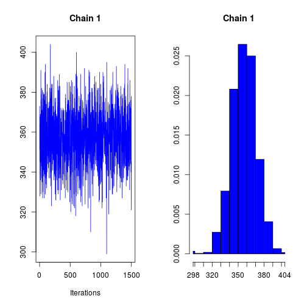

```r
## Convergence diagnostic to see if more we need to discard any
## iterations or entire chains: compute the number of outliers for
## each iteration for each chain
out <- mcmc_get_outliers(tanTagm)

## Using coda S3 objects to produce trace plots and histograms
plot(out[[1]], col = "blue", main = "Chain 1")
```

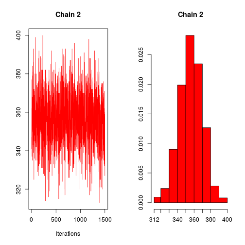

```r
plot(out[[2]], col = "red", main = "Chain 2")
```

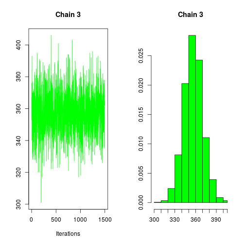

```r
plot(out[[3]], col = "green", main = "Chain 3")
```

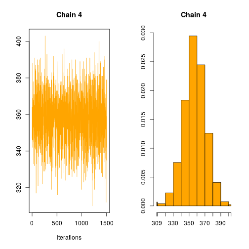

```r
plot(out[[4]], col = "orange", main = "Chain 4")
```

We can use the *coda* package to produce summaries of our chains. Here is the `coda` summary for the first chain.

```r
## all chains average around 360 outliers
summary(out[[1]])
```

```
##
## Iterations = 1:1500
## Thinning interval = 1
## Number of chains = 1
## Sample size per chain = 1500
##
## 1. Empirical mean and standard deviation for each variable,
##    plus standard error of the mean:
##
##           Mean             SD       Naive SE Time-series SE
##        357.301         13.864          0.358          0.358
##
## 2. Quantiles for each variable:
##
##  2.5%   25%   50%   75% 97.5%
##   329   348   357   367   384
```

In this case our chains looks very good. They all oscillate around an average of 360 outliers. There is no observed monotonicity in our output. However, for a more rigorous and unbiased analysis of convergence we can calculate the Gelman diagnostics using the *coda* package [@Gelman:1992,@Brools:1998]. This statistics is often refered to as $\hat{R}$ or the potential scale reduction factor. The idea of the Gelman diagnostics is to so compare the inter and intra chain variance. The ratio of these quantities should be close to one. The actual statistics computed is more complicated, but we do not go deeper here and a more detailed and in depth discussion can be found in the references. The *coda* package also reports the $95\%$ upper confidence interval of the $\hat{R}$ statistic.

```r
## Can check gelman diagnostic for convergence (values less than <1.05
## are good for convergence)
gelman.diag(out) ## the Upper C.I. is 1 so mcmc has clearly converged
```

```
## Potential scale reduction factors:
##
##      Point est. Upper C.I.
## [1,]          1          1
```

We can also look at the Gelman diagnostics statistics for pairs of chains.

```r
## We can also check individual pairs of chains for convergence
gelman.diag(out[1:2]) # the upper C.I is 1.01
```

```
## Potential scale reduction factors:
##
##      Point est. Upper C.I.
## [1,]          1       1.01
```

```r
gelman.diag(out[c(1,3)]) # the upper C.I is 1
```

```
## Potential scale reduction factors:
##
##      Point est. Upper C.I.
## [1,]          1          1
```

```r
gelman.diag(out[3:4]) # the upper C.I is 1
```

```
## Potential scale reduction factors:
##
##      Point est. Upper C.I.
## [1,]          1          1
```

## 4.2 Manually manipulating MCMC chains

This section explains how to manually manipulate our MCMC chains.

### 4.2.1 Discarding entire chains

Here we demonstrate how to discard chains that may not have converged. Including chains that have not converged in downstream analysis is likely to lead to nonsensical results. As an example, we demonstrate how to remove the second chain from our domwnstream analysis.

```r
## Our chains look really good but let us discard chain 2, as an
## example in case we didn't believe it had converged.  It would be
## possible to remove more than one chain e.g. to remove 2 and 4 using
## c(2, 4).
newTanMcmc <- tanTagm[-2]

## Let check that it looks good
newTanMcmc
```

```
## Object of class "MCMCParams"
## Method: TAGM.MCMC
## Number of chains: 3
```

```r
length(newTanMcmc) == (nChains - 1)
```

```
## [1] TRUE
```

```r
## Let have a look at our first chain
tanChain1 <- pRoloc:::chains(newTanMcmc)[[1]]
tanChain1@n ## Chain has 1500 iterations.
```

```
## [1] 1500
```

We could repeat the convergence diagnostics of the previous section to check for convergence again.

## 4.3 Discarding iterations from each chain

We are happy that our chains have conveged. Let us recap where our analysis up until this point. We have 3 chains each with 1500 iterations. We now demonstrate how to discard iterations from individual chains, since they may have converged some number of iteration into the analysis. Let us use only the iterations of last half of the remaining three chains. This also speeds up computations, however too few iterations in the further analysis is likely to lead to poor results. We find that using at least $1000$ iterations for downstream analysis leads to stable results.

```r
n <- (tanChain1@n)/2 # Number of iterations to keep 750
tanTagm2 <- mcmc_burn_chains(newTanMcmc, n)
```

`tanTagm2` is now an object of class `MCMCParams` with 3 chains each with each 750 iterations.

```r
## Check tanTagmParams object
pRoloc:::chains(tanTagm2)[[1]]
```

```
## Object of class "MCMCChain"
##  Number of components: 11
##  Number of proteins: 677
##  Number of iterations: 750
```

```r
pRoloc:::chains(tanTagm2)[[2]]
```

```
## Object of class "MCMCChain"
##  Number of components: 11
##  Number of proteins: 677
##  Number of iterations: 750
```

```r
pRoloc:::chains(tanTagm2)[[3]]
```

```
## Object of class "MCMCChain"
##  Number of components: 11
##  Number of proteins: 677
##  Number of iterations: 750
```

## 4.4 Processing and summarising MCMC results

### 4.4.1 Populating the summary slot

The summary slot of the `tanTagm2` is currently empty, we can now populate the summary slot of `tanTagm2` using the `tagmMcmcProcess` function.

```r
## This will automatically pool chains to produce summary (easy to
## create single summaries by subsetting)
tanTagm2 <- tagmMcmcProcess(tanTagm2)

## Let look at this object
summary(tanTagm2@summary@posteriorEstimates)
```

```
##       tagm.allocation tagm.probability tagm.probability.notOutlier
##  ER           :196    Min.   :0.3055   Min.   :0.0002031
##  PM           :192    1st Qu.:0.8439   1st Qu.:0.1712611
##  Ribosome 40S : 75    Median :0.9810   Median :0.6001312
##  mitochondrion: 61    Mean   :0.8927   Mean   :0.5278532
##  Proteasome   : 49    3rd Qu.:0.9980   3rd Qu.:0.8603698
##  Ribosome 60S : 32    Max.   :1.0000   Max.   :0.9982244
##  (Other)      : 72
##  tagm.probability.Outlier tagm.probability.lowerquantile
##  Min.   :0.001776         Min.   :0.001053
##  1st Qu.:0.139630         1st Qu.:0.591425
##  Median :0.399869         Median :0.942714
##  Mean   :0.472147         Mean   :0.769211
##  3rd Qu.:0.828739         3rd Qu.:0.995483
##  Max.   :0.999797         Max.   :0.999988
##
##  tagm.probability.upperquantile tagm.mean.shannon
##  Min.   :0.4961                 Min.   :0.0000254
##  1st Qu.:0.9698                 1st Qu.:0.0141329
##  Median :0.9959                 Median :0.0911157
##  Mean   :0.9655                 Mean   :0.2386502
##  3rd Qu.:0.9994                 3rd Qu.:0.4050057
##  Max.   :1.0000                 Max.   :1.3051988
##
```

For a sanity check, let us re-check the diagnostics. This is re-computed when we excute the `tagmMcmcProcess` function and located in a `diagnostics` slot.

```r
## Recomputed diagnostics
tanTagm2@summary@diagnostics
```

```
##              Point est. Upper C.I.
## outlierTotal    1.00021   1.000274
```

Let us look at a summary of the analysis.

```r
summary(tanTagm2@summary@tagm.joint)
```

```
##   Cytoskeleton             ER             Golgi
##  Min.   :0.0000000   Min.   :0.0000   Min.   :0.0000000
##  1st Qu.:0.0000000   1st Qu.:0.0000   1st Qu.:0.0000000
##  Median :0.0000040   Median :0.0000   Median :0.0000002
##  Mean   :0.0227762   Mean   :0.2826   Mean   :0.0503043
##  3rd Qu.:0.0004646   3rd Qu.:0.9232   3rd Qu.:0.0046922
##  Max.   :0.7798512   Max.   :0.9993   Max.   :0.9993792
##     Lysosome         mitochondrion          Nucleus
##  Min.   :0.0000000   Min.   :0.0000000   Min.   :0.0000000
##  1st Qu.:0.0000001   1st Qu.:0.0000000   1st Qu.:0.0000000
##  Median :0.0000016   Median :0.0000000   Median :0.0000000
##  Mean   :0.0167424   Mean   :0.0916050   Mean   :0.0365126
##  3rd Qu.:0.0000793   3rd Qu.:0.0000158   3rd Qu.:0.0000059
##  Max.   :0.9795195   Max.   :0.9998841   Max.   :0.9999886
##    Peroxisome              PM             Proteasome
##  Min.   :0.0000000   Min.   :0.000000   Min.   :0.0000000
##  1st Qu.:0.0000000   1st Qu.:0.000000   1st Qu.:0.0000000
##  Median :0.0000002   Median :0.000003   Median :0.0000002
##  Mean   :0.0055262   Mean   :0.278256   Mean   :0.0726235
##  3rd Qu.:0.0000232   3rd Qu.:0.764944   3rd Qu.:0.0005521
##  Max.   :0.8831085   Max.   :0.999998   Max.   :0.9979738
##   Ribosome 40S       Ribosome 60S
##  Min.   :0.000000   Min.   :0.0000000
##  1st Qu.:0.000000   1st Qu.:0.0000000
##  Median :0.000000   Median :0.0000001
##  Mean   :0.096071   Mean   :0.0470258
##  3rd Qu.:0.001051   3rd Qu.:0.0001129
##  Max.   :0.996639   Max.   :0.9885391
```

### 4.4.2 Appending results to an MSnSet

The `pRoloc` function `tagmPredict` can be used to append protein MCMC results to the feature data of our object of class `MSnSet`. This creates new columns in the feature data of the `MSnSet`, which can be used for final analysis of our data.

```r
## We can now use tagmPredict
tan2009r1 <- tagmPredict(tan2009r1, params = tanTagm2)
```

## 4.5 Visualising MCMC results

### 4.5.1 Visualising prediction results

Now that we have processed our chains, checked convergence and summarised the results into our `MSnset`; we can interrogate our data for novel biological results. We use the `plot2D` function to view the probabilitic allocations of proteins to sub-cellular niches.

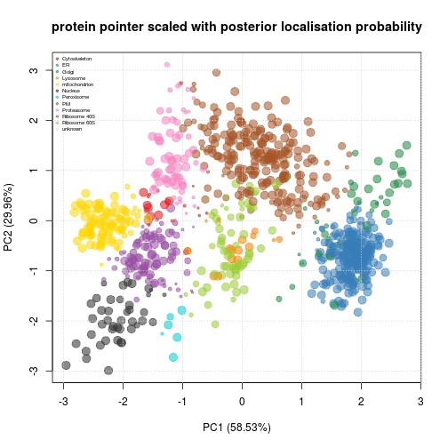

```r
## Create prediction point size
ptsze <- exp(fData(tan2009r1)$tagm.mcmc.probability) - 1

## Create plot2D with pointer scaled with probability
plot2D(tan2009r1,
       fcol = "tagm.mcmc.allocation",
       cex = ptsze,
       main = "protein pointer scaled with posterior localisation probability")

addLegend(object = tan2009r1, where = "topleft", cex = 0.5)
```

### 4.5.2 Visualising allocation uncertainty

By using the Shannon entropy we can globally visualise uncertainty. Proteins can be scaled with their Shannon entropy and we note that proteins with high Shannon entropy have high uncertainty.

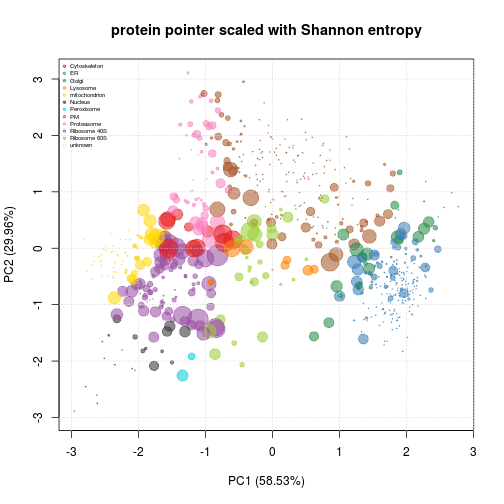

```r
## Visualise shannon entropy
## Create prediction point size
ptsze2 <- 3 * fData(tan2009r1)$tagm.mcmc.mean.shannon
plot2D(tan2009r1, fcol = "tagm.mcmc.allocation", cex = ptsze2,
       main = "protein pointer scaled with Shannon entropy")
addLegend(object = tan2009r1, where = "topleft", cex = 0.5)
```

### 4.5.3 Extracting proteins of interest

Our data can be interrogated in other ways. We might be interested in all the proteins that were confidently assigned as outliers. A GO enrichment analysis could be performed on these proteins, since they may reveal biologically interesting results.

```r
## Get outlier lists proteins with probability greater than 0.95 of being outlier
outliers <- rownames(tan2009r1)[fData(tan2009r1)$tagm.mcmc.outlier > 0.95]
outliers
```

```
##  [1] "P04412"   "Q7KJ73"   "Q00174"   "Q9Y105"   "Q9VTZ5"   "B7Z0C1"
##  [7] "P46150"   "Q9VN14"   "Q9VU58"   "Q9V498"   "Q9V496"   "P06607"
## [13] "Q7K0F7"   "Q9V8R9"   "Q9VT75"   "A8JNJ6"   "Q8SZ38"   "Q960V7"
## [19] "Q7KA66"   "P98163"   "Q9VE24"   "Q9VE79"   "A8JV22"   "O96824"
## [25] "P23226"   "Q9VKF0"   "Q9VZL6"   "P11584"   "Q9VDK9"   "Q9V4A7"
## [31] "Q9W303"   "Q8MLV1"   "Q07152"   "Q9VEE9"   "Q9VXE5"   "P13395"
## [37] "Q7JYX2"   "P91938"   "Q9U969"   "Q7JZY1"   "O18388"   "P02844"
## [43] "NO_ID_7"  "P27716"   "Q9W478"   "Q8IN49"   "O18337"   "A1Z6L9"
## [49] "Q86P66"   "Q9VK04"   "Q9GU68"   "Q8INH5"   "O18333"   "P54351"
## [55] "P15215"   "P33450"   "Q24298"   "Q9W404"   "Q9VPQ2"   "Q9VF20"
## [61] "Q8IPU3"   "Q7JVX3"   "Q9VV60"   "Q9V427"   "Q7JQR3"   "P52295"
## [67] "A8JRB8"   "Q9VTU4"   "Q24007"   "B8A403"   "Q00963"   "Q94887"
## [73] "Q4AB31"   "Q95SY7"   "O15943"   "Q9VDV3"   "B7Z0D3"   "Q9VLT3"
## [79] "Q9VUQ7"   "Q9VAG2"   "A1Z6H7"   "Q27415"   "Q9VHL2"   "NO_ID_16"
## [85] "Q94518"   "Q7KN94"   "P29742"   "Q9VXB0"   "B7Z036"   "Q8IRH6"
## [91] "P17917"   "M9PDB2"   "Q9VVA0"   "Q9VHP0"
```

### 4.5.4 Extracting information for individual proteins

We might be interested in analysing the localisation of individual proteins and interrogating which other potential localisations these proteins might have. A violin plot of the probabilistic allocation of the following protein Q9VCK0 is visualised. This demonstrates and quantifies the uncertainty in the allocation of this protein.

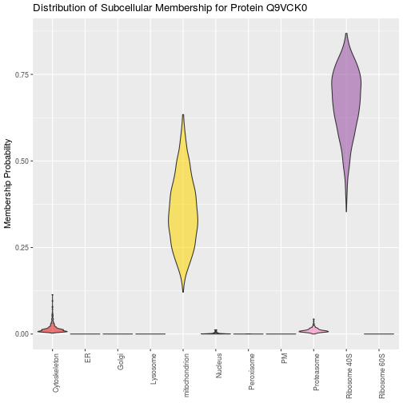

```r
plot(tanTagm, "Q9VCK0")
```